# Homework 03

Answers

## 0.1 Before you begin

This homework exercise involves having you answer some questions, write some code, and create a nice HTML file with your results. When asked different questions, simply either type your coded or written responses after the ANSWER message. When asked to write code to complete sections, type your code in the empty code blocks that follow the ANSWER message. After adding that code, you must make sure that it will execute. So remember to run your code by highlighting it and pressing the RUN button or pressing CONTROL+ENTER.

If your code does not execute, then RMarkdown won’t know what you are telling it to do and your HTML file will not be produced. Also, don’t create your HTML file until you finish.

## 0.2 1. Installing libraries using RStudio

Use the RStudio interface to install packages/libraries. Go to the Tools option and select Install Packages. Type the package name(s) correctly using the proper letter casing. Also, make sure that you check the box to Install Dependecies. Do not install with code.

Install the following package(s): - lattice

## 0.3 2. Loading libraries

After you finished the install, use the library() function to load the library by adding your R code in the empty block below (between the ```). **ANSWER:**

```r
library("lattice")
```

## 0.4 3. Checking your working directory

Always make sure that your working directory is correct. Use the getwd() function to check it by adding the code to the block. Verify that your working directory is correct. If it wasn’t correct, save your work, set it in the global settings and then restart RStudio. If that does not work use the setwd() function or please see Lukas or myself for help. **ANSWER:**

```r
getwd()
```

```
## [1] "C:/Users/Lukas/Dropbox/Exercises/Homework"
```

## 0.5 4. Descriptive statistics

A. How do outliers (extreme scores) affect measures of central tendency? **ANSWER:** Outliers can have dramatic influences on some measures of central tendency. Although outliers do not necessarily influence the mode and only influence the median slightly, they do influence the mean by shifting it in the direction of the outlier.

B. What information does the variance and the mean provide about a distribution of scores? **ANSWER:** The variance provides a measure of dispersion of a distribution; it is a measure of average squared deviation from the mathematical center, the mean. The variance is calculated as SS/N.

## 0.6 5. Understanding properties for inferential statistics

A. Six months after a divorce, the former wife and husband each take a test that measures divorce adjustment. The wife’s score is 63, and the husband’s score is 59; over all the mean score for divorced women on this test is 60 with a standard deviation of 6; the mean score for divorced men on this test is 55 with a standard deviation of 4. If greater scores represent better adjustment, has the wife or the husband adjusted better to the divorce in relation to other divorced women and men of the same gender? Please explain your answer to yourself verbally as a means of testing whether you are able to describe the concepts appropriately. **ANSWER:** Simply consider how many standard deviations they are from their respective means. Wife = 63; women mean = 60, sd = 6. She is half of a standard deviation above the mean. Husband = 59; men mean = 55, sd = 4. He is also above the mean by 1 standard deviation. Thus, the seems to have adjusted better than his wife, relative of course, to other husbands and wives.

B. A psychologist has studied eye fatigue using a particular measure, which she administers to students after they have worked for one hour typing on a computer. On this measure, she has found that the distribution follows a normal curve defined by mean = 80 and a standard deviation = 8. We can use the pnorm() function to retrn the probability associated with scoring below a certain value. The pnorm() function uses 3 arguments to do this: (1) the value that you want to test, (2) the mean of the distribution, and (3) the standard deviation of the distribution.

I’ve provided an example to get you started.

```r
# Example: For determining the probability of a score falling the below 70:
pnorm(70, mean = 80, sd = 8)
```

```
## [1] 0.1056498
```

C. Keep in mind that pnorm() is returning a *p* value that is *LESS* than the value you enter as the first argument of pnorm(). *Hint:* You might need to do some subtraction or draw out your distribution by hand to see what you are really doing. You can complete the items by adding your code below the comment line for each value. Use the pnorm() function, determine the probability that students have Z scores that are: **ANSWER:**

```r
# 1. Below 2.10
pnorm(2.10, mean = 0, sd = 1)
```

```
## [1] 0.9821356
```

```r
# 2. Below -1.78
pnorm(-1.78, mean = 0, sd = 1)
```

```
## [1] 0.03753798
```

```r
# 3. Above .45
1 - pnorm(.45, mean = 0, sd = 1)
```

```
## [1] 0.3263552
```

```r
# 4. Above -1.5
1 - pnorm(-1.5, mean = 0, sd = 1)
```

```
## [1] 0.9331928
```

## 0.7 6. Calculating z scores using the formula

You can use the z-score formula z = (x - mean)/sd to determine the z score that corresponds to a raw score of 70 when that parent distribution is a normal distribution defined by a mean = 80 and sd = 8. We can assign that value to an R object named z70. For example:

```r
z70 <- (70 - 80)/8
z70 # let's see what's in the object
```

```
## [1] -1.25
```

A. Use this logic to calculate the z score that corresponds to an WAIS IQ score of 120, for which the IQ distribution is assumed to be normally distributed with a mean = 100 and sd = 15. **ANSWER:**

```r
z120 <- (120 - 100)/15
z120
```

```
## [1] 1.333333
```

If we had z scores and we knew that our distribution was a standard normal distribution defined by a mean = 0 and sd = 1, we could also find that probability of someone scoring less than a z score of that z70 value. For example:

```r
pnorm(-1.25, mean = 0, sd = 1) # if we pass the -1.25 value into pnorm()
```

```
## [1] 0.1056498
```

```r
pnorm(z70, mean = 0, sd = 1)   # we get the same thing if we pass the object z70 into pnorm() because z70 = -1.25
```

```
## [1] 0.1056498
```

B. Now, do the same thing as demonstrated above for the z score that corresponds to your IQ score of 120. And of course, make sure that you pay attention to whether your z scores are positive (above) or negative (below) the mean.

```r
pnorm(z120, mean = 0, sd = 1)
```

```
## [1] 0.9087888
```

## 0.8 7. Applying the logic to the real world

Suppose that you are designing an instrument panel for a large industrial machine. The machine requires the person using it to reach 2 feet from a particular position. The reach for this position for adult women is known to have a mean of 2.8 feet with a standard deviation of .5 feet. The reach for adult men is known to have a mean of 3.1 feet with a standard deviation of .6 feet. Both women’s and men’s reach from this position is distributed normally.

If this machine design is implemented: * What percentage of women will be unable to work on this instrument panel? * What percentage of men will be unable to work on this instrument panel?

A. Use the appropriate R function to answer this question and assign that to the objects f and m. I’ve started this for you by creating the objects, but you now need to write the function with the proper arguments. Simply replace the 0 with your function. **ANSWER:**

```r
f <- pnorm(2, mean = 2.8, sd = .5)
m <- pnorm(2, mean = 3.1, sd = .6)
```

These will be probability values, so we will need to convert them to percentages by multiplying by 100. I’ll do this for you and show you how we can have RMarkdown add your answer for you automatically by calling the object inside the code. You will see that I use the round() function to round the returned value to only 2 decimal points or else you will have many decimals. **IMPORTANT:** *DO NOT type your answer below because your R code will do it for you when you knit your HTML file when you are finished.*

Percent of Women **ANSWER:** 5.48% Percent of Men **ANSWER:** 3.34%

## 0.9 8. Reading a file

A. Read in the cdc.csv file using the read.csv() function and assign the file to a data frame object named health by adding your code below. Remember, the name of the csv file is a string, so you will have to put your quotes around the file name. Yes, of course, execute it to make sure you did this correctly. If R throws an error because it cannot find the file, remember to make sure it’s in your Psyc109 directory or perhaps you spelled something incorrectly. **ANSWER:**

```r
health <- read.csv("cdc.csv")
```

## 0.10 9. Examining the data frame’s contents

A. Apply the str() function in order to examine the structure of your data frame. **ANSWER:**

```r
str(health)
```

```
## 'data.frame':    20000 obs. of  9 variables:
##  $ genhlth : Factor w/ 5 levels "excellent","fair",..: 3 3 3 3 5 5 5 5 3 3 ...
##  $ exerany : int  0 0 1 1 0 1 1 0 0 1 ...
##  $ hlthplan: int  1 1 1 1 1 1 1 1 1 1 ...
##  $ smoke100: int  0 1 1 0 0 0 0 0 1 0 ...
##  $ height  : int  70 64 60 66 61 64 71 67 65 70 ...
##  $ weight  : int  175 125 105 132 150 114 194 170 150 180 ...
##  $ wtdesire: int  175 115 105 124 130 114 185 160 130 170 ...
##  $ age     : int  77 33 49 42 55 55 31 45 27 44 ...
##  $ gender  : Factor w/ 2 levels "f","m": 2 1 1 1 1 1 2 2 1 2 ...
```

B. Is age the 5th, 6th, or 8th variable? **ANSWER:** The 8th

C. How many levels are there for genhlth? **ANSWER:** 5

## 0.11 10. Examining shape and normality

Take a look at the shape of the age variable.

A. Use the hist() function to produce a histogram for age. **ANSWER:**

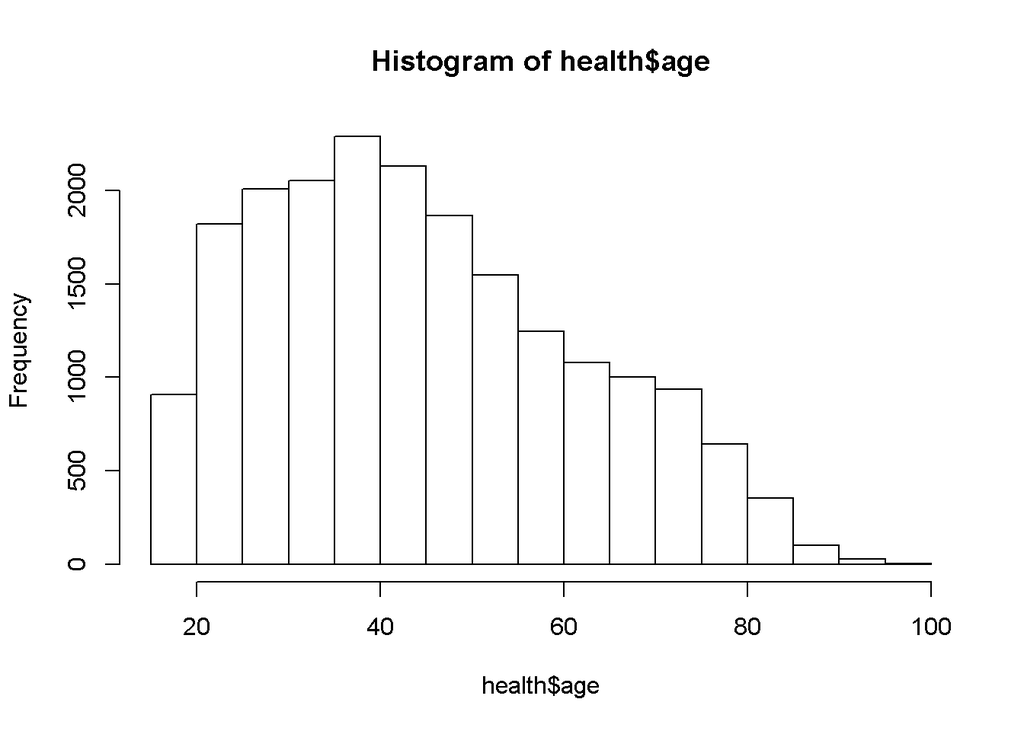

```r
hist(health$age)
```

B. Check the skewness() and kurtosis() of age. If you need to load a library in order to do so, remember to use the library() function. **ANSWER:**

```r
library("moments")
skewness(health$age)
```

```
## [1] 0.4516664
```

```r
kurtosis(health$age)
```

```
## [1] 2.345038
```

C. Now use both the qqnorm() and the qqline() functions to plot a quantile-quantile plot so that you can examine whether the age variable is normal in shape; the qqline() function fits a line to the qqnorm plot. If the points fall along that line, age will be roughly normal in shape. Simply type the functions and put your variable object inside the parentheses as you did above. **ANSWER:**

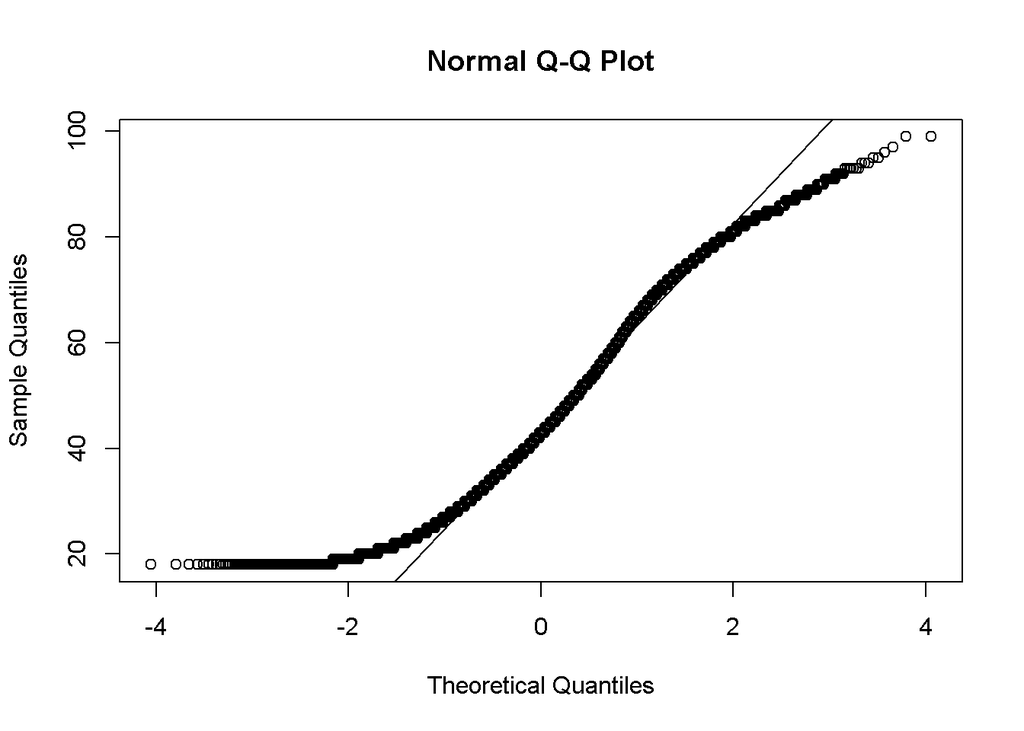

```r
qqnorm(health$age)
qqline(health$age)
```